# IODS course project

Anton JyrkiÃ¤inen

# About the project

*Introduction to open data science is about discovering the patterns hidden behind numbers in matrices and arrays. The course introduces you to open data science using tools such as [R](https://www.r-project.org/), [RStudio](https://www.rstudio.com/), RMarkdown, and [Github](https://github.com/). The course will include coding in R, analyzing, modelling and maintaining a course diary.*

## Github repository

github.com/ahjyrkia/IODS-project

# Regression and model validation

Week 2, Anton JyrkiÃ¤inen

### Part 1

The data used is from a study which investigates the relationship between teaching, learning approaches and exam results of the students.

Link to data [here](http://www.helsinki.fi/~kvehkala/JYTmooc/JYTOPKYS3-data.txt) and link to metadata [here](http://www.helsinki.fi/~kvehkala/JYTmooc/JYTOPKYS2-meta.txt).

First we import the data which we wrangled and saved locally in the first part of the exercise. The data is set to a variable `lrn14` using read.table.

```r
lrn14 <- read.table("C:/Users/Anton/Documents/IODS-project/learning2014.txt")
```

We also need to import few dependancies for later use:

```r
library(GGally)
```

```r
library(ggplot2)
library(dplyr)
```

By using `str()` we can have a look at the structure of the data:

```r
str(lrn14)
```

```
## 'data.frame':    166 obs. of  7 variables:
##  $ gender  : Factor w/ 2 levels "F","M": 1 2 1 2 2 1 2 1 2 1 ...
##  $ Age     : int  53 55 49 53 49 38 50 37 37 42 ...
##  $ Attitude: int  37 31 25 35 37 38 35 29 38 21 ...
##  $ deep    : num  3.58 2.92 3.5 3.5 3.67 ...
##  $ stra    : num  3.38 2.75 3.62 3.12 3.62 ...
##  $ surf    : num  2.58 3.17 2.25 2.25 2.83 ...
##  $ Points  : int  25 12 24 10 22 21 21 31 24 26 ...
```

The output gives us meta information about the data in general and about each column itself: amount of rows and colums, name of the variables, data type and the first values. There’s seven variables: gender, global attitude toward statistics, exam points and three variables “deep” (deep questions), “surf” (surface questions), “stra” (strategic questions) which are composed of means calculated from answering various questions. These three, in the same order as mentioned previously, stand for “intention to maximize understanding, with a true commitment to learning”, “memorizing without understanding, with a serious lack of personal engagement in the learning process” and “the ways students organize their studying”.

The questions were measured with a scale from 1 to 5 with (1 = disagree, 5 = agree). The data covers answers from 183 participants of which 67% were female and had a mean age of 25.6 years. Observations with 0 exam points are excluded from the data in the wrangling part of the exercise.

Using `dim()` we get an output which gives as the dimensions of the dataset.

```r
dim(lrn14)
```

```
## [1] 166   7
```

### Part 2

The `ggpairs()` functions provides us a matrix of plots which consists of density plots, bar plot, histograms, scatter plots, correlation coefficients and box plots. These plots represent all the possible combinations of the variables.

Using the dataset with `ggpairs()` we generate a graphical overview:

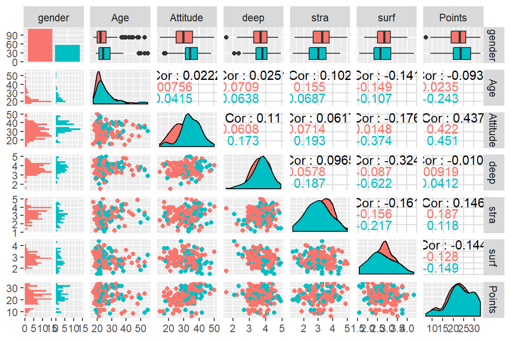

```r
p <- ggpairs(lrn14, mapping = aes(col = gender), lower = list(combo = wrap("facethist", bins = 20)))
p
```

And with `summary()` we get a summary of the variables:

```r
summary(lrn14)
```

```
##  gender       Age           Attitude          deep            stra
##  F:110   Min.   :17.00   Min.   :14.00   Min.   :1.583   Min.   :1.250
##  M: 56   1st Qu.:21.00   1st Qu.:26.00   1st Qu.:3.333   1st Qu.:2.625
##          Median :22.00   Median :32.00   Median :3.667   Median :3.188
##          Mean   :25.51   Mean   :31.43   Mean   :3.680   Mean   :3.121
##          3rd Qu.:27.00   3rd Qu.:37.00   3rd Qu.:4.083   3rd Qu.:3.625
##          Max.   :55.00   Max.   :50.00   Max.   :4.917   Max.   :5.000
##       surf           Points
##  Min.   :1.583   Min.   : 7.00
##  1st Qu.:2.417   1st Qu.:19.00
##  Median :2.833   Median :23.00
##  Mean   :2.787   Mean   :22.72
##  3rd Qu.:3.167   3rd Qu.:27.75
##  Max.   :4.333   Max.   :33.00
```

Just looking at the density plots they give us an rough idea how each variable is distributed. All the variables seem to be close to normally distributed expect for “age” and “deep”. The scale for age is from 17 to 55 so it makes sense for the density plot to be heavily distributed to the young side since the participants of the survey are students. In the “deep” variable there is quite interesting bias towards agreeing to a lot to the questions. From the summary we see that the mean to answering “deep questions” is 3.68.

### Part 3

A regression model is made with `lm()`. As for the formula we will be using “Points” as dependent variable and “Attitude”, “stra” and “deep” for explanatory variables. Also a summary of the regression model is generated with `summary()`:

```r
lm1 <- lm(formula = Points ~ Attitude + stra + deep, data = lrn14)
lm1
```

```
##
## Call:
## lm(formula = Points ~ Attitude + stra + deep, data = lrn14)
##
## Coefficients:
## (Intercept)     Attitude         stra         deep
##     11.3915       0.3525       0.9621      -0.7492
```

The intercept is the value of y (“Points”) when all the x (“Attitude”,“stra”,“deep”) are 0. The other values are the slope in the regression model.

```r
summary(lm1)
```

```
##
## Call:
## lm(formula = Points ~ Attitude + stra + deep, data = lrn14)
##
## Residuals:
##      Min       1Q   Median       3Q      Max
## -17.5239  -3.4276   0.5474   3.8220  11.5112
##
## Coefficients:
##             Estimate Std. Error t value Pr(>|t|)
## (Intercept) 11.39145    3.40775   3.343  0.00103 **
## Attitude     0.35254    0.05683   6.203 4.44e-09 ***
## stra         0.96208    0.53668   1.793  0.07489 .
## deep        -0.74920    0.75066  -0.998  0.31974
## ---
## Signif. codes:  0 '***' 0.001 '**' 0.01 '*' 0.05 '.' 0.1 ' ' 1
##
## Residual standard error: 5.289 on 162 degrees of freedom
## Multiple R-squared:  0.2097, Adjusted R-squared:  0.195
## F-statistic: 14.33 on 3 and 162 DF,  p-value: 2.521e-08
```

The residuals are difference between the observed value of the dependant variable and the predicted value. Each data point has a residual. The residuals should be normally distributed and their sum should always be 0. Residuals can reveal unexplained patterns in data which is fitted to the model.

The coefficients show us the estimate, standard error, t-value and p-value. Standard error is an estimate of the standard deviation of the coefficient estimate. T-value is estimate divided by standard error. The p-value shows the probability of observing A t-value larger than the one presented. P-value basically indicates if there’s evidence against the null hypothesis. Low p-value indicates strong evidence against the null hypothesis and high p-value indicates weak evidence or no evidence against the null hypothesis.

The output also gives us a “signif. codes” which make it easier to interpret the results with just a glance. In this case “Attitude” received p-value of under 0.01 which means there is strong evidence that the null hypothesis does not hold. This means that it is unlikely that “Attitude” does not correlate with “points”. “stra” had p-value between 0.05 and 0.1 which indicates weak evidence that the null hypothesis does not hold. Variable “deep” does not have statistically signifant relationship with the target variable.

Next we fit the model again without variable “deep”:

```r
lm1 <- lm(formula = Points ~ Attitude + stra, data = lrn14)
lm1
```

```
##
## Call:
## lm(formula = Points ~ Attitude + stra, data = lrn14)
##
## Coefficients:
## (Intercept)     Attitude         stra
##      8.9729       0.3466       0.9137
```

```r
summary(lm1)
```

```
##
## Call:
## lm(formula = Points ~ Attitude + stra, data = lrn14)
##
## Residuals:
##      Min       1Q   Median       3Q      Max
## -17.6436  -3.3113   0.5575   3.7928  10.9295
##
## Coefficients:
##             Estimate Std. Error t value Pr(>|t|)
## (Intercept)  8.97290    2.39591   3.745  0.00025 ***
## Attitude     0.34658    0.05652   6.132 6.31e-09 ***
## stra         0.91365    0.53447   1.709  0.08927 .
## ---
## Signif. codes:  0 '***' 0.001 '**' 0.01 '*' 0.05 '.' 0.1 ' ' 1
##
## Residual standard error: 5.289 on 163 degrees of freedom
## Multiple R-squared:  0.2048, Adjusted R-squared:  0.1951
## F-statistic: 20.99 on 2 and 163 DF,  p-value: 7.734e-09
```

Without the variable “deep” we get similar results with a bit higher p-values for “Attitude” and “stra” but still within the same signifiance codes as before. Also the r-squared and f-statistics stay relatively the same.

### Part 4

Residual standard error is the standard deviation of the residuals.

R-squared tells us how close the data is to the fitted regression line. The higher the R-squared, the better the model fits the data. If the R-squared was 100% the fitted values would all be on the fitted regression line. Difference between multiple and adjusted R-squared is that adjusted R-squared takes the phenomenon of R-squared automatically increasing when more explanatory variables are added to the model. The adjusted R-squared is at 19.51% which indicates that the data points will be quite scattered around the fitted regression line. This indicates that producing predictions with this model would be somewhat inaccurate.

F-statistic is variaton between sample means divided by variance within the samples. The p-value in the f-statistics indicate that atleast some of the results are statistically significant. If the p-value here would indicate insignificance we couldn’t reject the null hypothesis.

### Part 5

Residuals vs fitted values:

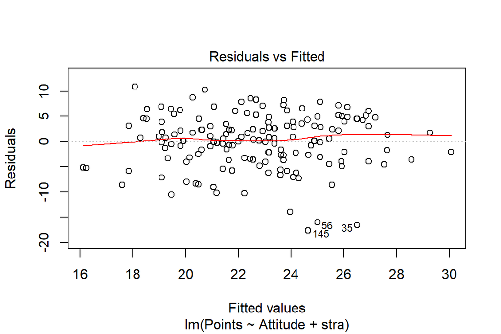

```r
plot(lm1, which = c(1))
```

We can see that variability of the points are about the equal so that would be good. There seems to be no signs here that would indicate a problem with the model.

Normal Q-Q:

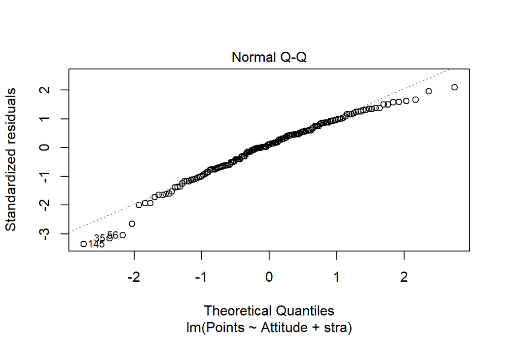

```r
plot(lm1, which = c(2))
```

Residuals vs leverage:

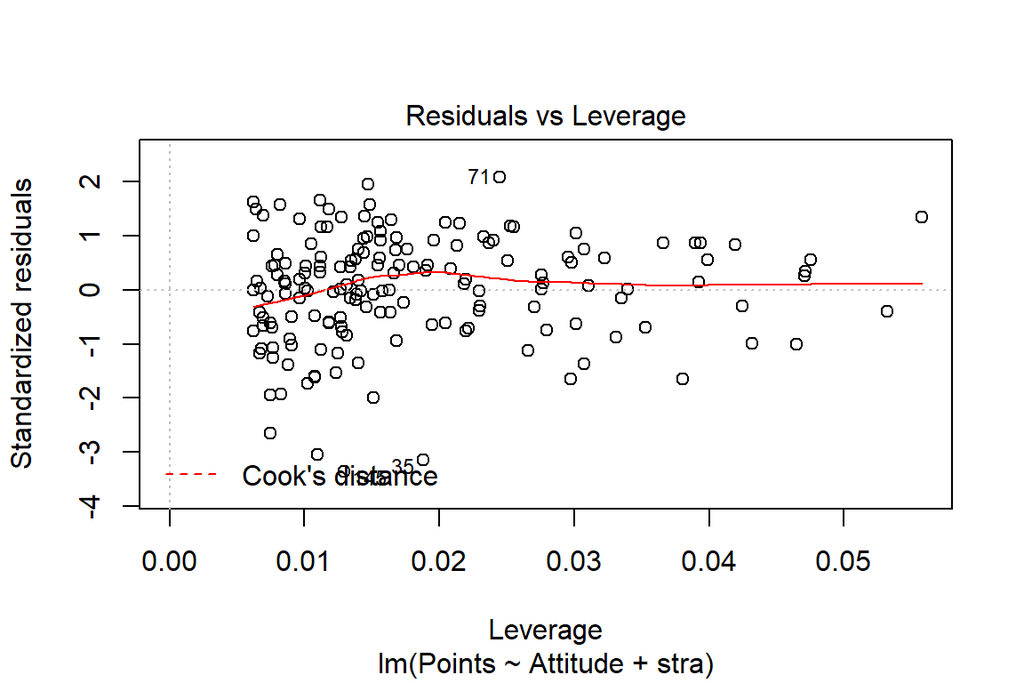

```r
plot(lm1, which = c(5))
```

This plot shows us if there are extreme values that are influental. Even though there is some extreme values they are no influental since they more or less follow the trend of the other values. Excluding influental point would radically change the results which don’t seem to be the case here.

# Logistic regression

Week 3, Anton JyrkiÃ¤inen

Dependancies used:

```r
library(dplyr);
library(ggplot2);
library(tidyr);
```

First we import the data which we wrangled and saved locally in the first part of the exercise. The data is set to a variable `alc` using read.table.

```r
alc <- read.table("http://s3.amazonaws.com/assets.datacamp.com/production/course_2218/datasets/alc.txt", sep = ",", header=TRUE)
```

Variables in the dataset:

```r
names(alc)
```

```
##  [1] "school"     "sex"        "age"        "address"    "famsize"
##  [6] "Pstatus"    "Medu"       "Fedu"       "Mjob"       "Fjob"
## [11] "reason"     "nursery"    "internet"   "guardian"   "traveltime"
## [16] "studytime"  "failures"   "schoolsup"  "famsup"     "paid"
## [21] "activities" "higher"     "romantic"   "famrel"     "freetime"
## [26] "goout"      "Dalc"       "Walc"       "health"     "absences"
## [31] "G1"         "G2"         "G3"         "alc_use"    "high_use"
```

The dataset consists of data collected from school reports and questionnaires from two different Portugese schools regarding the performance in two subjects: mathematics and Portugese.

Link to the data [here](https://archive.ics.uci.edu/ml/machine-learning-databases/00320/) and link to metadata [here](https://archive.ics.uci.edu/ml/datasets/Student+Performance).

Absences, studytime and grades go together quite well when doing analysis of school performance. I expect that absences are positively correlated and studytime and grades negatively correlated with high alcohol use. Gender will probably have no difference in this and will not be statistically significant Therefor the variables to be used are `absences`, `studytime`, `G3` and `sex`.

Barplot of each variable we’re interested in:

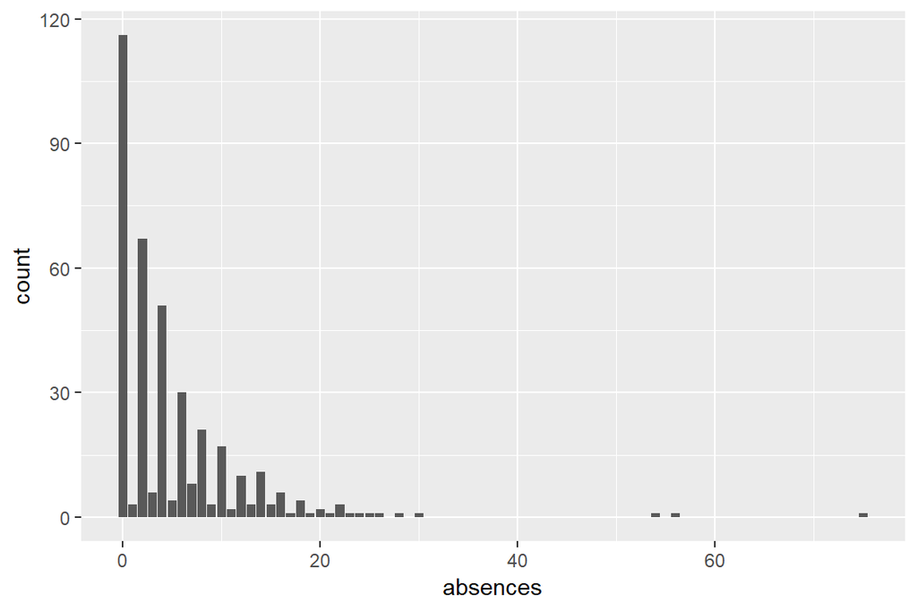

```r
ggplot(data = alc, aes(x = absences)) + geom_bar()
```

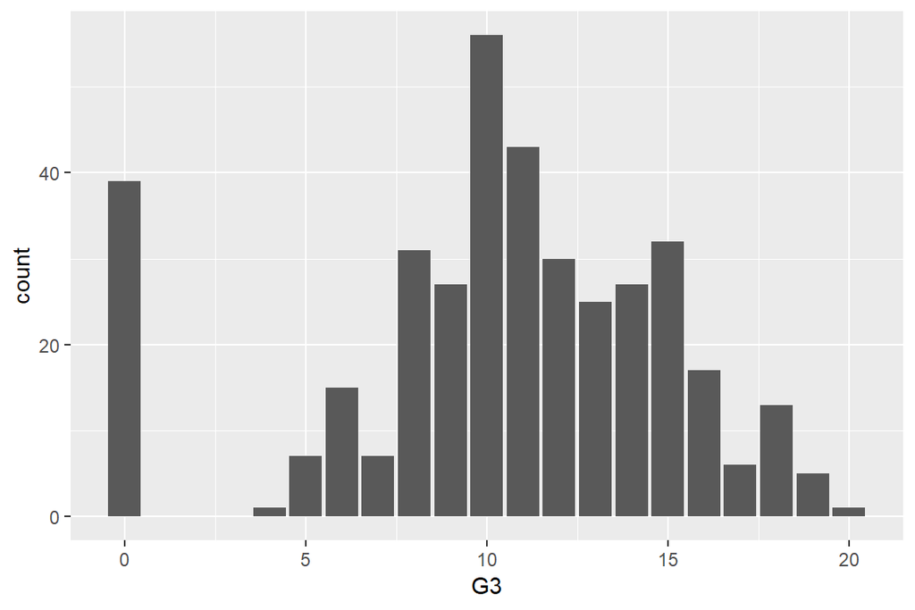

```r
ggplot(data = alc, aes(x = G3)) + geom_bar()
```

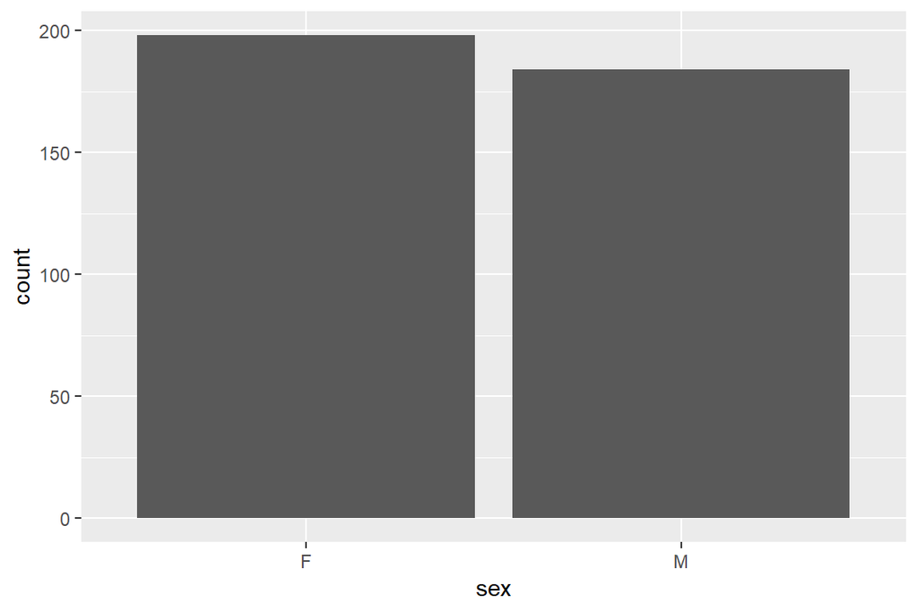

```r
ggplot(data = alc, aes(x = sex)) + geom_bar()
```

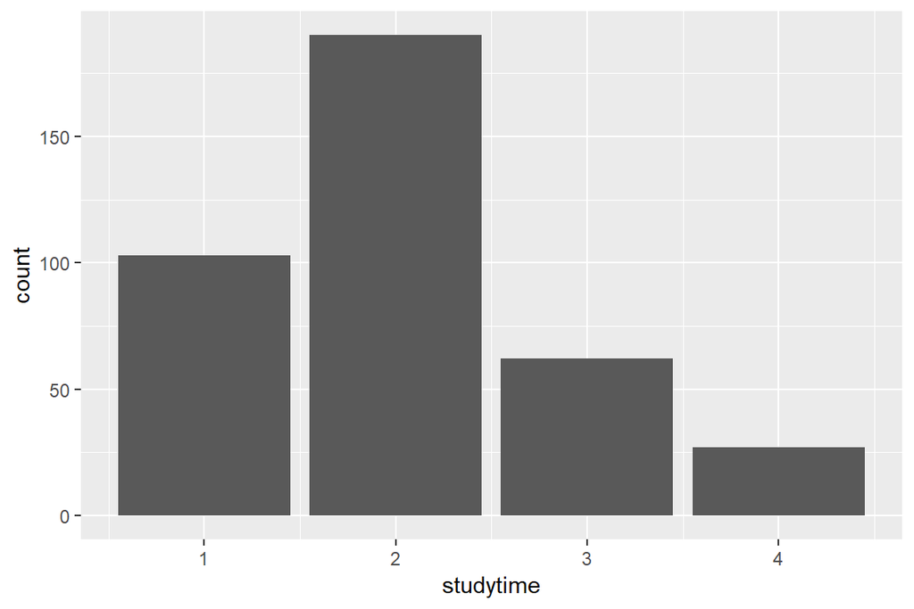

```r
ggplot(data = alc, aes(x = studytime)) + geom_bar()
```

In the barplots we can observe the distribution of the variables we’ve chosen. We can see that it is more common to have none or less absences. Most of the students are getting average or a bit above average grades.There’s also quite large number of students receiving 0 grade. There’s slightly more female students than male students. Majority of the students seem to study less than 2 hours or 2-5 hours weekly.

Boxplots:

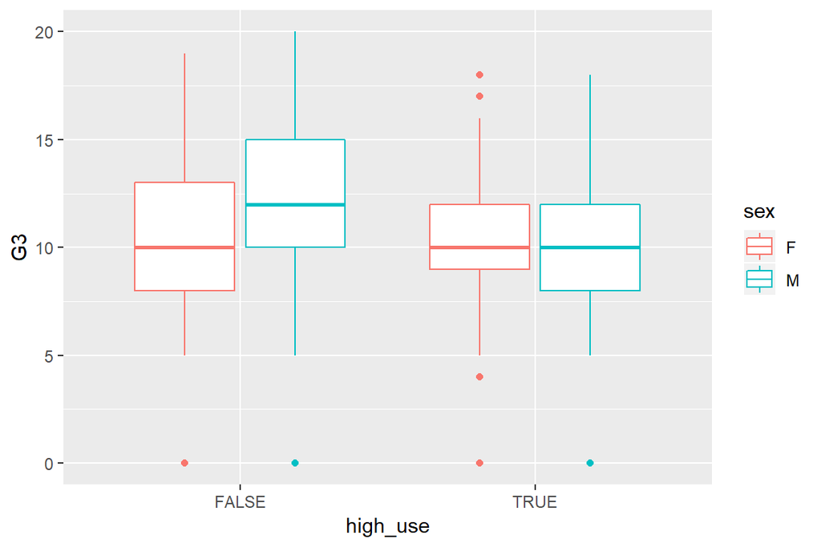

```r
g1 <- ggplot(alc, aes(x = high_use, y = G3, col = sex))
g1 + geom_boxplot()
```

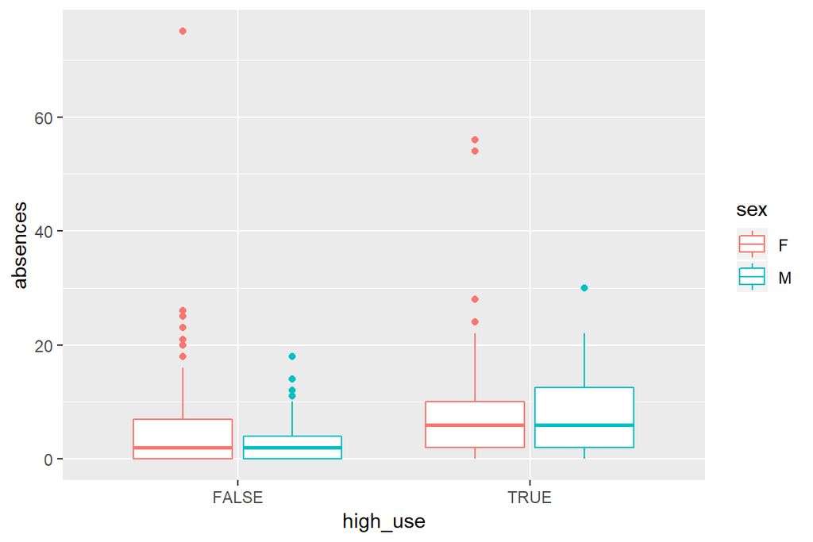

```r
g2 <- ggplot(alc, aes(x = high_use, y = absences, col = sex))
g2 + geom_boxplot()
```

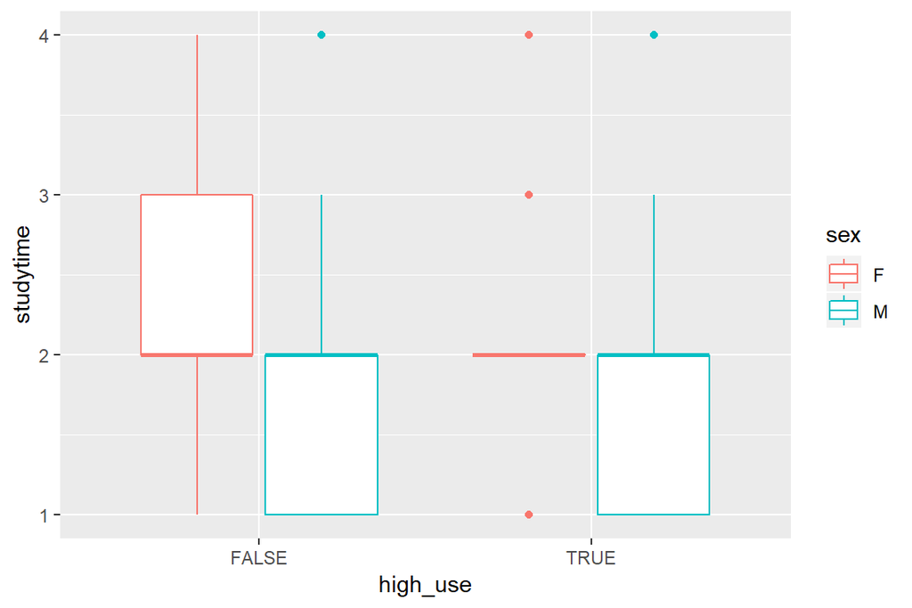

```r
g2 <- ggplot(alc, aes(x = high_use, y = studytime, col = sex))
g2 + geom_boxplot()
```

Grade means by group:

```r
alc %>% group_by(sex, high_use) %>% summarise(count = n(), mean_grade = mean(G3))
```

```
## # A tibble: 4 x 4
## # Groups:   sex [?]
##   sex   high_use count mean_grade
##   <fct> <lgl>    <int>      <dbl>
## 1 F     FALSE      157       9.69
## 2 F     TRUE        41      10.4
## 3 M     FALSE      113      11.6
## 4 M     TRUE        71       9.97
```

Among the female students there’s a grade mean increase of 0.71 when the person is considered to have high use of alcohol. Among the male students there’s a large grade drop of 1.63 points if the student is categorized to the high use of alcohol group.

Absence mean by group:

```r
alc %>% group_by(sex, high_use) %>% summarise(count = n(), mean_absences = mean(absences))
```

```
## # A tibble: 4 x 4
## # Groups:   sex [?]
##   sex   high_use count mean_absences
##   <fct> <lgl>    <int>         <dbl>
## 1 F     FALSE      157          4.97
## 2 F     TRUE        41          8.90
## 3 M     FALSE      113          3.19
## 4 M     TRUE        71          7.41
```

We can observe that the high alcohol use has a negative impact on the absences of the student. With the female students there’s 3.93 more school absences and with the male students the absences are more than doubled.

Study time mean by group:

```r
alc %>% group_by(sex, high_use) %>% summarise(count = n(), mean_studytime = mean(studytime))
```

```
## # A tibble: 4 x 4
## # Groups:   sex [?]
##   sex   high_use count mean_studytime
##   <fct> <lgl>    <int>          <dbl>
## 1 F     FALSE      157           2.34
## 2 F     TRUE        41           2
## 3 M     FALSE      113           1.88
## 4 M     TRUE        71           1.62
```

Average studying times seem also to suffer from high alcohol use with lower mean studying times in both groups.

Summary of logistic regression with our variables and high/low alcohol consumption set as the target variable:

```r
m <- glm(high_use ~ sex + absences + G3 + studytime, data = alc, family = "binomial")
summary(m)
```

```
##
## Call:
## glm(formula = high_use ~ sex + absences + G3 + studytime, family = "binomial",
##     data = alc)
##
## Deviance Residuals:
##     Min       1Q   Median       3Q      Max
## -2.6894  -0.8391  -0.5951   1.1034   2.1852
##
## Coefficients:
##             Estimate Std. Error z value Pr(>|z|)
## (Intercept) -0.64915    0.45507  -1.426 0.153725
## sexM         0.84250    0.25698   3.278 0.001044 **
## absences     0.07076    0.01821   3.887 0.000102 ***
## G3          -0.02575    0.02635  -0.977 0.328574
## studytime   -0.41864    0.16119  -2.597 0.009398 **
## ---
## Signif. codes:  0 '***' 0.001 '**' 0.01 '*' 0.05 '.' 0.1 ' ' 1
##
## (Dispersion parameter for binomial family taken to be 1)
##
##     Null deviance: 462.21  on 381  degrees of freedom
## Residual deviance: 416.74  on 377  degrees of freedom
## AIC: 426.74
##
## Number of Fisher Scoring iterations: 4
```

From the summary of the model we can see that our original hypothesis does not hold. Gender does in fact seem to be statistically significant and the final grade is not. The summary reveals that it is more probable to be in the high use group if the student is male and the high use variable correlates with absences and studytime variables. The deviance residuals seem to be fine since they are roughly close to centered to zero and symmetrical. Nul deviance and residual deviance can be used to compare models and to calculate R-square and p-value. AIC can also be used to comparing to other models.

Odds ratios with their confidence intervals:

```r
OR <- coef(m) %>% exp
CI <- confint(m) %>% exp
cbind(OR, CI)
```

```
##                    OR     2.5 %    97.5 %
## (Intercept) 0.5224889 0.2125860 1.2719337
## sexM        2.3221692 1.4096724 3.8686858
## absences    1.0733272 1.0379854 1.1144115
## G3          0.9745836 0.9257160 1.0267950
## studytime   0.6579430 0.4751282 0.8953331
```

The `OR` column is the exponent of the coefficient which can be interpret as odds ratio between a unit change in the corresponging explanatory variable. Therefor the row `sexM` can be interpret as male students being ~2.3 times more likely to be heavy user of alcohol than the female students.

```r
m <- glm(high_use ~ sex + absences + G3 + studytime, data = alc, family = "binomial")
```

Let’s explore the predictive power of the model:

```r
probabilities <- predict(m, type = "response")
alc <- mutate(alc, probability = probabilities)
alc <- mutate(alc, prediction = probability > 0.5)
```

First we used the predict()-function to get the probability of high use. Then added the predicted probabiliets to `alc` and then alter the table so it has a column `prediction` which has a boolean value as predictor of high use. If the probability was higher than 0.5 the value is set to `TRUE` otherwise `FALSE`.

Let’s look at a confusion matrix:

```r
table(high_use = alc$high_use, prediction = alc$prediction)
```

```
##         prediction
## high_use FALSE TRUE
##    FALSE   262    8
##    TRUE     85   27
```

Tabulate the target variable versus the prediction:

```r
table(high_use = alc$high_use, prediction = alc$prediction) %>% prop.table %>% addmargins
```

```
##         prediction
## high_use      FALSE       TRUE        Sum
##    FALSE 0.68586387 0.02094241 0.70680628
##    TRUE  0.22251309 0.07068063 0.29319372
##    Sum   0.90837696 0.09162304 1.00000000
```